# Severe Weather Human and Property Costs

Robert Wieland

February 11, 2018

## Synopsis

This project is the second project in the Reproducible Research course on Coursera. The goal of this project is to use tools such as R markdown to produce reproducible research. To do so, we will be analyzing a data set as described per the project [instructions](https://www.coursera.org/learn/reproducible-research/peer/OMZ37/course-project-2) below:

> Storms and other severe weather events can cause both public health and economic problems for communities and municipalities. Many severe events can result in fatalities, injuries, and property damage, and preventing such outcomes to the extent possible is a key concern.

> This project involves exploring the U.S. National Oceanic and Atmospheric Administration’s (NOAA) storm database. This database tracks characteristics of major storms and weather events in the United States, including when and where they occur, as well as estimates of any fatalities, injuries, and property damage.

The goal of the analysis of this data set is to determine:

- Across the United States, which types of events are most harmful with respect to population health
- Across the United States, which types of events have the greatest economic consequences.

## Data Processing

### The Data Set

The initial data set described as per the project instruction [page](https://www.coursera.org/learn/reproducible-research/peer/OMZ37/course-project-2):

> The data for this assignment come in the form of a comma-separated-value file compressed via the bzip2 algorithm to reduce its size. You can download the file directly from the course web site:
- [Storm Data](https://d396qusza40orc.cloudfront.net/repdata%2Fdata%2FStormData.csv.bz2)

> There is also some documentation of the database available. Here you will find how some of the variables are constructed/defined.
- National Weather Service [Storm Data Documentation](https://d396qusza40orc.cloudfront.net/repdata%2Fpeer2_doc%2Fpd01016005curr.pdf)
- National Climatic Data Center Storm Events [FAQ](https://d396qusza40orc.cloudfront.net/repdata%2Fpeer2_doc%2FNCDC%20Storm%20Events-FAQ%20Page.pdf)

> The events in the database start in the year 1950 and end in November 2011. In the earlier years of the database there are generally fewer events recorded, most likely due to a lack of good records. More recent years should be considered more complete.

### Importing the data set into R

First, we create a directory for storing the storm data,

then download the data from the course web site.

```r
dataFile = "data/StormData.csv.bz2"
if (!file.exists(dataFile)) {
  dataUrl = "https://d396qusza40orc.cloudfront.net/repdata%2Fdata%2FStormData.csv.bz2"
  download.file(dataUrl, dataFile, "auto")
}
```

Finally the data is into R using read.csv (Note: bz2 files can be read directly with read.csv())

```r
stormData = read.csv(dataFile)
```

### Characterizing the Data Set

The data set is rather large and has 37 variables.

```r
dim(stormData)
```

```
## [1] 902297     37
```

```r
names(stormData)
```

```
##  [1] "STATE__"    "BGN_DATE"   "BGN_TIME"   "TIME_ZONE"  "COUNTY"
##  [6] "COUNTYNAME" "STATE"      "EVTYPE"     "BGN_RANGE"  "BGN_AZI"
## [11] "BGN_LOCATI" "END_DATE"   "END_TIME"   "COUNTY_END" "COUNTYENDN"
## [16] "END_RANGE"  "END_AZI"    "END_LOCATI" "LENGTH"     "WIDTH"
## [21] "F"          "MAG"        "FATALITIES" "INJURIES"   "PROPDMG"
## [26] "PROPDMGEXP" "CROPDMG"    "CROPDMGEXP" "WFO"        "STATEOFFIC"
## [31] "ZONENAMES"  "LATITUDE"   "LONGITUDE"  "LATITUDE_E" "LONGITUDE_"
## [36] "REMARKS"    "REFNUM"
```

Since we are only interested in the event type, effects on human health, and property damage, we will select only those variables which are relevant to this study.

```r
stormData = stormData[,c("EVTYPE", "FATALITIES", "INJURIES", "PROPDMG", "PROPDMGEXP", "CROPDMG", "CROPDMGEXP")]
```

We will rename each of these variables to have a more descriptive name.

```r
names(stormData) = c("event.type", "fatalities", "injuries", "property.damage", "property.damage.exponent", "crop.damage", "crop.damage.exponent")
```

Let’s look at a summary of this subset of the storm data.

```r
summary(stormData)
```

```
##              event.type       fatalities          injuries
##  HAIL             :288661   Min.   :  0.0000   Min.   :   0.0000
##  TSTM WIND        :219940   1st Qu.:  0.0000   1st Qu.:   0.0000
##  THUNDERSTORM WIND: 82563   Median :  0.0000   Median :   0.0000
##  TORNADO          : 60652   Mean   :  0.0168   Mean   :   0.1557
##  FLASH FLOOD      : 54277   3rd Qu.:  0.0000   3rd Qu.:   0.0000
##  FLOOD            : 25326   Max.   :583.0000   Max.   :1700.0000
##  (Other)          :170878
##  property.damage   property.damage.exponent  crop.damage
##  Min.   :   0.00          :465934           Min.   :  0.000
##  1st Qu.:   0.00   K      :424665           1st Qu.:  0.000
##  Median :   0.00   M      : 11330           Median :  0.000
##  Mean   :  12.06   0      :   216           Mean   :  1.527
##  3rd Qu.:   0.50   B      :    40           3rd Qu.:  0.000
##  Max.   :5000.00   5      :    28           Max.   :990.000
##                    (Other):    84
##  crop.damage.exponent
##         :618413
##  K      :281832
##  M      :  1994
##  k      :    21
##  0      :    19
##  B      :     9
##  (Other):     9
```

From this summary we can see that we may need to make some alterations to the data set:

1. The variables property.damage and property.damage.exponent as well as crop.damage and crop.damage.exponent should be merged into a single numeric variables
2. Some event types may need to be renamed to facilitate later analysis (ex: TSTM WIND to THUNDERSTORM WIND)

We will begin by merging the damage values.

### Property and Crop Damage

```r
summary(stormData[stormData$property.damage.exponent == "",])
```

```
##               event.type       fatalities          injuries
##  HAIL              :196662   Min.   :  0.0000   Min.   :  0.0000
##  TSTM WIND         :157095   1st Qu.:  0.0000   1st Qu.:  0.0000
##  FLASH FLOOD       : 21319   Median :  0.0000   Median :  0.0000
##  THUNDERSTORM WINDS:  8951   Mean   :  0.0121   Mean   :  0.0443
##  TORNADO           :  8805   3rd Qu.:  0.0000   3rd Qu.:  0.0000
##  HEAVY SNOW        :  8695   Max.   :583.0000   Max.   :437.0000
##  (Other)           : 64407
##  property.damage    property.damage.exponent  crop.damage
##  Min.   : 0.00000          :465934           Min.   :  0.0000
##  1st Qu.: 0.00000   -      :     0           1st Qu.:  0.0000
##  Median : 0.00000   ?      :     0           Median :  0.0000
##  Mean   : 0.00113   +      :     0           Mean   :  0.5121
##  3rd Qu.: 0.00000   0      :     0           3rd Qu.:  0.0000
##  Max.   :75.00000   1      :     0           Max.   :990.0000
##                     (Other):     0
##  crop.damage.exponent
##         :461616
##  K      :  3865
##  M      :   443
##  B      :     4
##  0      :     3
##  ?      :     2
##  (Other):     1
```

```r
summary(stormData[stormData$crop.damage.exponent == "",])
```

```
##               event.type       fatalities          injuries
##  TSTM WIND         :213340   Min.   :  0.0000   Min.   :   0.0000
##  HAIL              :206353   1st Qu.:  0.0000   1st Qu.:   0.0000
##  TORNADO           : 51055   Median :  0.0000   Median :   0.0000
##  FLASH FLOOD       : 32598   Mean   :  0.0188   Mean   :   0.1779
##  THUNDERSTORM WINDS: 19906   3rd Qu.:  0.0000   3rd Qu.:   0.0000
##  FLOOD             : 11704   Max.   :583.0000   Max.   :1700.0000
##  (Other)           : 83457
##  property.damage  property.damage.exponent  crop.damage
##  Min.   :  0.00          :461616           Min.   :0.0e+00
##  1st Qu.:  0.00   K      :149067           1st Qu.:0.0e+00
##  Median :  0.00   M      :  7395           Median :0.0e+00
##  Mean   : 11.07   0      :   211           Mean   :1.8e-05
##  3rd Qu.:  0.00   5      :    26           3rd Qu.:0.0e+00
##  Max.   :996.00   1      :    25           Max.   :4.0e+00
##                   (Other):    73
##  crop.damage.exponent
##         :618413
##  ?      :     0
##  0      :     0
##  2      :     0
##  B      :     0
##  k      :     0
##  (Other):     0
```

```r
exps = c("", "k", "K", "m", "M", "b", "B")
unique(stormData[!(stormData$property.damage.exponent %in% exps), "property.damage.exponent"])
```

```
##  [1] + 0 5 6 ? 4 2 3 h 7 H - 1 8
## Levels:  - ? + 0 1 2 3 4 5 6 7 8 B h H K m M
```

```r
unique(stormData[!(stormData$crop.damage.exponent %in% exps), "crop.damage.exponent"])
```

```
## [1] ? 0 2
## Levels:  ? 0 2 B k K m M
```

It is not clear how to interpret “-”, “+”, “?”, or “h” so these will also be dropped from the analysis. We will now define a function to convert damage and exponent values into a single damage value.

```r
convert.damage = function(damage, exponent) {
  # numeric damage
  # character exponent
  df = data.frame(c(10^3, 10^6, 10^9), row.names = c("k", "m", "b"))
  if (tolower(exponent) %in% row.names(df))
    return(damage * df[tolower(exponent),])
  if (!is.na(as.numeric(exponent))) {
    return(damage * 10 ^ as.numeric(exponent))
  return(NA)
  }
}
```

We will use the dplyr library to apply this to the storm data set.

```r
library(dplyr)
```

We now use the convert.damage function to convert damage and exponent values into single damage values. Also, since we will no longer need the exponent values, we will drop them from our data set.

```r
stormData = stormData %>%
  mutate(property.damage = convert.damage(property.damage, property.damage.exponent),
         crop.damage = convert.damage(crop.damage, crop.damage.exponent)) %>%
  select(-c(property.damage.exponent, crop.damage.exponent))
summary(stormData)
```

```
##              event.type       fatalities          injuries
##  HAIL             :288661   Min.   :  0.0000   Min.   :   0.0000
##  TSTM WIND        :219940   1st Qu.:  0.0000   1st Qu.:   0.0000
##  THUNDERSTORM WIND: 82563   Median :  0.0000   Median :   0.0000
##  TORNADO          : 60652   Mean   :  0.0168   Mean   :   0.1557
##  FLASH FLOOD      : 54277   3rd Qu.:  0.0000   3rd Qu.:   0.0000
##  FLOOD            : 25326   Max.   :583.0000   Max.   :1700.0000
##  (Other)          :170878
##  property.damage     crop.damage
##  Min.   :0.00e+00   Min.   :0.000e+00
##  1st Qu.:0.00e+00   1st Qu.:0.000e+00
##  Median :1.00e+03   Median :0.000e+00
##  Mean   :9.80e+05   Mean   :5.272e+07
##  3rd Qu.:1.00e+04   3rd Qu.:0.000e+00
##  Max.   :1.15e+11   Max.   :5.960e+11
##  NA's   :466255
```

We now have damage values which we can use in later analysis.

### Event Types

In section 7, the [Storm Data documentation](https://d396qusza40orc.cloudfront.net/repdata%2Fpeer2_doc%2Fpd01016005curr.pdf) specifies 46 event types which are included in the data set. We’ve created a vector called officialTypes which contains these events:

```r
officialTypes
```

```
##  [1] "avalanche"                "blizzard"
##  [3] "coastal flood"            "cold/wind chill"
##  [5] "debris flow"              "dense fog"
##  [7] "dense smoke"              "drought"
##  [9] "dust devil"               "dust storm"
## [11] "excessive heat"           "extreme cold/wind chill"
## [13] "flash flood"              "flood"
## [15] "freezing fog"             "frost/freeze"
## [17] "funnel cloud"             "hail"
## [19] "heavy rain"               "heavy snow"
## [21] "high surf"                "high wind"
## [23] "hurricane/typhoon"        "ice storm"
## [25] "lakeshore flood"          "lake-effect snow"
## [27] "lightning"                "marine hail"
## [29] "marine high wind"         "marine strong wind"
## [31] "marine thunderstorm wind" "rip current"
## [33] "seiche"                   "sleet"
## [35] "storm tide"               "strong wind"
## [37] "thunderstorm wind"        "tornado"
## [39] "tropical depression"      "tropical storm"
## [41] "tsunami"                  "volcanic ash"
## [43] "waterspout"               "wildfire"
## [45] "winter storm"             "winter weather"
```

However, within the event.type variable there are many more than 46 event types.

```r
types = unique(stormData$event.type)
```

```r
head(types, n = 30)
```

```
##  [1] TORNADO                      TSTM WIND
##  [3] HAIL                         FREEZING RAIN
##  [5] SNOW                         ICE STORM/FLASH FLOOD
##  [7] SNOW/ICE                     WINTER STORM
##  [9] HURRICANE OPAL/HIGH WINDS    THUNDERSTORM WINDS
## [11] RECORD COLD                  HURRICANE ERIN
## [13] HURRICANE OPAL               HEAVY RAIN
## [15] LIGHTNING                    THUNDERSTORM WIND
## [17] DENSE FOG                    RIP CURRENT
## [19] THUNDERSTORM WINS            FLASH FLOOD
## [21] FLASH FLOODING               HIGH WINDS
## [23] FUNNEL CLOUD                 TORNADO F0
## [25] THUNDERSTORM WINDS LIGHTNING THUNDERSTORM WINDS/HAIL
## [27] HEAT                         WIND
## [29] LIGHTING                     HEAVY RAINS
## 985 Levels:    HIGH SURF ADVISORY  COASTAL FLOOD ... WND
```

This appears in part to be due to entries such as “TSTM WIND” which shorten “thunderstorm wind”, “THUNDERSTORM WINDS LIGHTNING” which combine the “thunderstorm wind” and “lightning” types, and “HURRICANE ERIN” which name the specific weather event. Let’s see how many exact matches there are. First, we convert event.type to lower case.

```r
stormData$event.type = tolower(stormData$event.type)
```

Then we check for entries with exact matches.

```r
matches = stormData$event.type %in% officialTypes
sum(matches) / length(matches)
```

```
## [1] 0.703039
```

It appears that we get about 70% coverage of the original data set with exact matches to the official event types. For the sake of time and simplicity, we will only use those event types with exact matches for this assignment. If we were to delve deeper into this data set, we would need to account for those other 30% that have no exact matches.

```r
stormData = stormData[matches,]
dim(stormData)
```

```
## [1] 634350      5
```

```r
unique(stormData$event.type)
```

```
##  [1] "tornado"                  "hail"
##  [3] "winter storm"             "heavy rain"
##  [5] "lightning"                "thunderstorm wind"
##  [7] "dense fog"                "rip current"
##  [9] "flash flood"              "funnel cloud"
## [11] "flood"                    "waterspout"
## [13] "high wind"                "blizzard"
## [15] "heavy snow"               "coastal flood"
## [17] "ice storm"                "avalanche"
## [19] "dust storm"               "sleet"
## [21] "dust devil"               "excessive heat"
## [23] "high surf"                "strong wind"
## [25] "winter weather"           "drought"
## [27] "tropical storm"           "wildfire"
## [29] "lake-effect snow"         "freezing fog"
## [31] "volcanic ash"             "frost/freeze"
## [33] "seiche"                   "tropical depression"
## [35] "extreme cold/wind chill"  "marine hail"
## [37] "hurricane/typhoon"        "cold/wind chill"
## [39] "marine high wind"         "tsunami"
## [41] "dense smoke"              "lakeshore flood"
## [43] "marine thunderstorm wind" "marine strong wind"
```

## Results

### Most Impactful Event Types on Event Casualties

We will use ggplot and ggpubr to create exploratory figures.

```r
library(ggplot2)
library(ggpubr)
```

To investigate the impact of various weather events on human casualties, we summarize fatalities and injuries by sum and mean.

```r
health.summary = stormData %>%
  group_by(event.type) %>%
  summarise(total.fatalities = sum(fatalities, na.rm = TRUE),
            average.fatalities = mean(fatalities, na.rm = TRUE),
            total.injuries = sum(injuries, na.rm = TRUE),
            average.injuries = mean(injuries, na.rm = TRUE),
            total.casualties = sum(fatalities + injuries, na.rm = TRUE),
            average.casualties = mean(fatalities + injuries, na.rm = TRUE)) %>%
  mutate(event.type = toupper(event.type))
```

For easy plotting of the summary data we will create a function that creates a plot of the top entries for a specified variable.

```r
top.x.bar = function(data, x, y, n = 5) {
  data = arrange(data, desc(data[[y]]))[1:n,]
  ggplot(data,
         aes_string(x = reorder(data[[x]], -data[[y]]), y = y)) +
    geom_bar(stat = "identity") +
    theme_classic() +
    theme(axis.text.x = element_text(angle = 50, hjust = 1),
          plot.margin = margin(2, 2, 2, 2)) +
    ylab(gsub("\\.", " ", y)) +
    xlab("")
}
```

We will now use this function to create plots of our summary statistics.

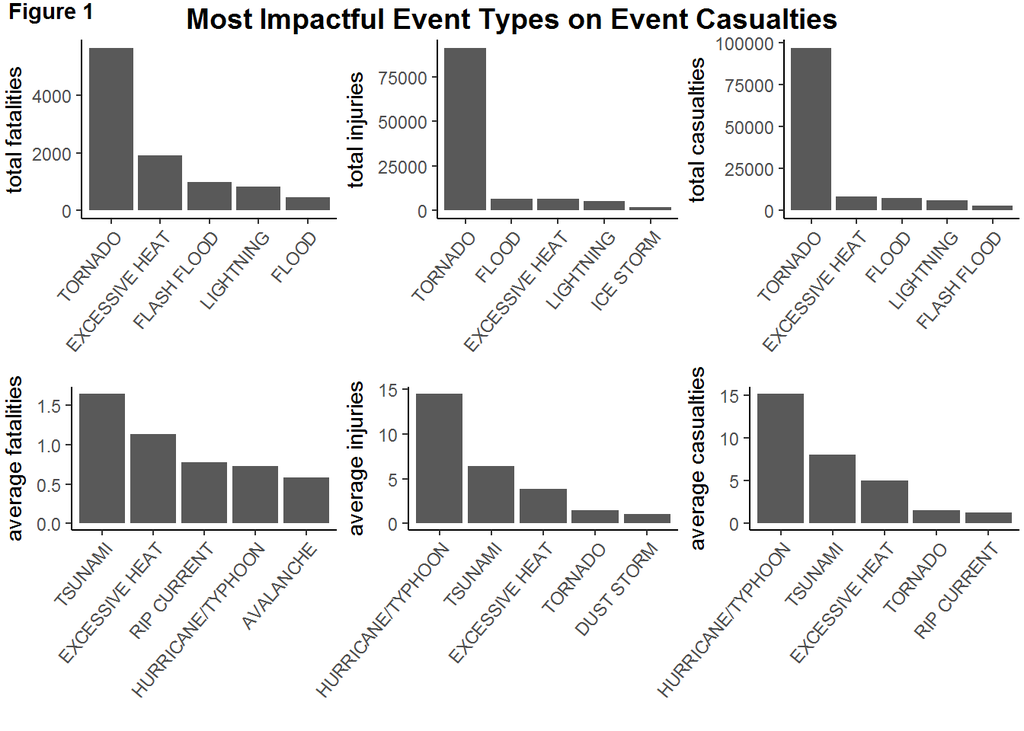

```r
tf = top.x.bar(health.summary, "event.type", "total.fatalities")
af = top.x.bar(health.summary, "event.type", "average.fatalities")
ti = top.x.bar(health.summary, "event.type", "total.injuries")
ai = top.x.bar(health.summary, "event.type", "average.injuries")
tc = top.x.bar(health.summary, "event.type", "total.casualties")
ac = top.x.bar(health.summary, "event.type", "average.casualties")
casualties.plot = ggarrange(tf, ti, tc, af, ai, ac)

annotate_figure(casualties.plot,
                top = text_grob("Most Impactful Event Types on Event Casualties", face = "bold", size = 14),
                fig.lab = "Figure 1", fig.lab.face = "bold")
```

We can see from this figure that tornadoes count for the most fatalities and injuries in the data set. However, on average tsunamis are the most deadly and hurricanes are the most injurious.

### Most Impactful Event Types on Event Damages

Now, we do the same thing but with event caused property and crop damages.

```r
damage.summary = stormData %>%
  group_by(event.type) %>%
  summarise(total.damage = sum(property.damage + crop.damage, na.rm = TRUE),
            ave.damage = mean(property.damage + crop.damage, na.rm = TRUE),
            total.property.damage = sum(property.damage, na.rm = TRUE),
            ave.property.damage = mean(property.damage, na.rm = TRUE),
            total.crop.damage = sum(crop.damage, na.rm = TRUE),
            ave.crop.damage = mean(crop.damage, na.rm = TRUE)) %>%
  mutate(event.type = toupper(event.type))
```

[figure not shown]

```r
tf = top.x.bar(damage.summary, "event.type", "total.damage")
af = top.x.bar(damage.summary, "event.type", "ave.damage")
ti = top.x.bar(damage.summary, "event.type", "total.property.damage")
ai = top.x.bar(damage.summary, "event.type", "ave.property.damage")
tc = top.x.bar(damage.summary, "event.type", "total.crop.damage")
ac = top.x.bar(damage.summary, "event.type", "ave.crop.damage")
casualties.plot = ggarrange(tf, ti, tc, af, ai, ac)
annotate_figure(casualties.plot,
                top = text_grob("Most Impactful Event Types on Event Casualties",
                                face = "bold",
                                size = 14),
                fig.lab = "Figure 2", fig.lab.face = "bold")
```

We can see that floods are responsible for the most total damage and property damage, but that drought is causes the most total crop damage. However, per event, hurricanes and typhoons cause more damage to both property and crops.